# Data Analysis Replication

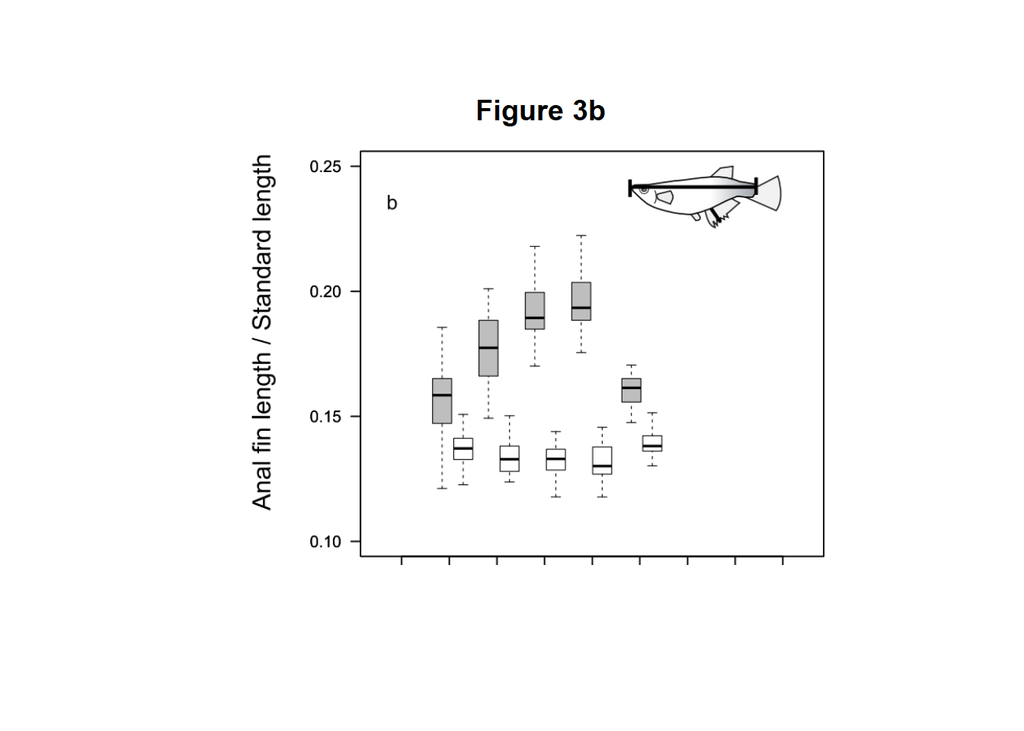

```r
plotImageArray(Figure3b, main = "Figure 3b") # plot of figure 3b
```

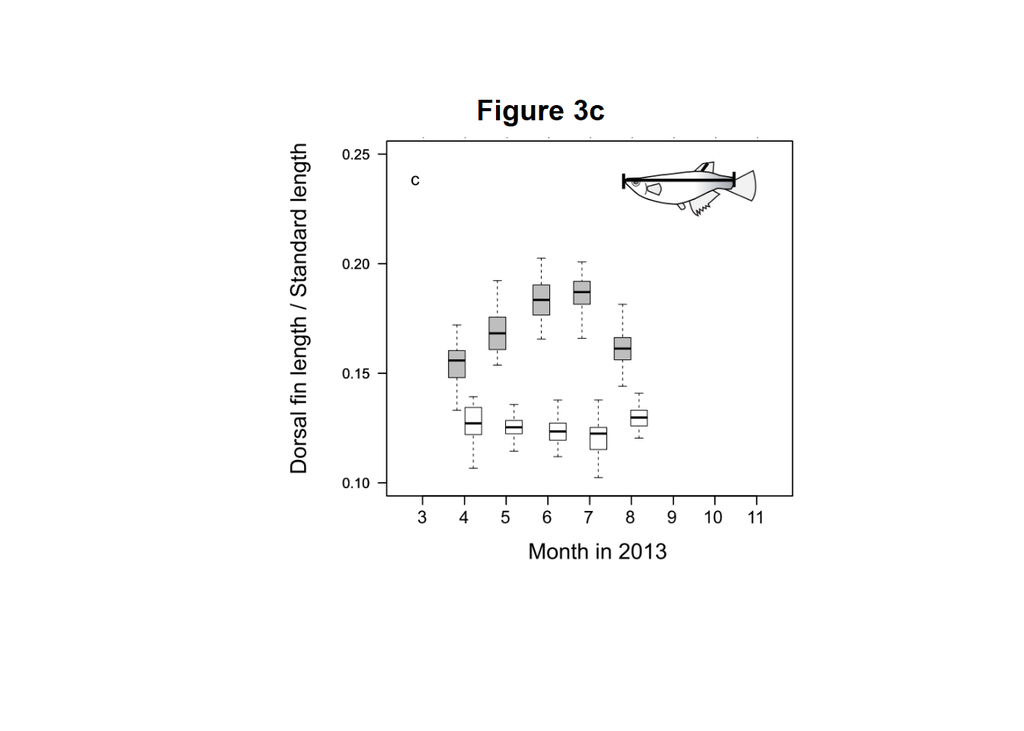

```r
plotImageArray(Figure3c, main = "Figure 3c") # plot of figure 3c
```

READ IN DATAFILES & ORGANIZE

```r
d2013 <- read_csv("https://raw.githubusercontent.com/MaxxRAM/Data-Analysis-Replication/main/data/SLvsFin_Data2013.csv", col_names = T)
head(d2013)
```

```
## # A tibble: 6 × 11
##       date  year month   day ordinal population sex      SL    BD   AFL   DFL
##      <dbl> <dbl> <dbl> <dbl>   <dbl> <chr>      <chr> <dbl> <dbl> <dbl> <dbl>
## 1 20130415  2013     4    15     104 aomori     m      22.0  4.23  3.37  3.25
## 2 20130415  2013     4    15     104 aomori     m      22.2  4.23  3.35  3.48
## 3 20130415  2013     4    15     104 aomori     m      21.4  3.97  3.40  3.09
## 4 20130415  2013     4    15     104 aomori     m      20.6  4.20  3.69  3.78
## 5 20130415  2013     4    15     104 aomori     m      21.1  4.24  3.26  3.36
## 6 20130415  2013     4    15     104 aomori     m      21.2  4.15  3.55  3.20
```

```r
d2013 <- d2013 |>
  select(sex, SL, AFL, DFL, month) # Isolate out only the columns of interest
head(d2013)
```

```
## # A tibble: 6 × 5
##   sex      SL   AFL   DFL month
##   <chr> <dbl> <dbl> <dbl> <dbl>
## 1 m      22.0  3.37  3.25     4
## 2 m      22.2  3.35  3.48     4
## 3 m      21.4  3.40  3.09     4
## 4 m      20.6  3.69  3.78     4
## 5 m      21.1  3.26  3.36     4
## 6 m      21.2  3.55  3.20     4
```

2013 ANOVA ANALYSIS OF AFL & DFL BY MONTH, BY SEX, AND THE MONTH:SEX INTERACTION

```r
AFLSL<- d2013$AFL / d2013$SL # creates the ratio of anal fin length to standard length
DFLSL<- d2013$DFL / d2013$SL # creates ratio of dorsal fin length to standard length

(m1<- aov(data = d2013, AFLSL ~ sex * as.factor(d2013$month)))
```

```
## Call:
##    aov(formula = AFLSL ~ sex * as.factor(d2013$month), data = d2013)
##
## Terms:
##                        sex as.factor(d2013$month) sex:as.factor(d2013$month)
## Sum of Squares  0.12633313             0.01216184                 0.01869351
## Deg. of Freedom          1                      3                          3
##                  Residuals
## Sum of Squares  0.03074539
## Deg. of Freedom        258
##
## Residual standard error: 0.01091642
## Estimated effects may be unbalanced
## 2 observations deleted due to missingness
```

```r
(m2<- aov(data = d2013, DFLSL ~ sex * as.factor(d2013$month)))
```

```
## Call:
##    aov(formula = DFLSL ~ sex * as.factor(d2013$month), data = d2013)
##
## Terms:
##                        sex as.factor(d2013$month) sex:as.factor(d2013$month)
## Sum of Squares  0.14365997             0.00889028                 0.01444552
## Deg. of Freedom          1                      3                          3
##                  Residuals
## Sum of Squares  0.02368801
## Deg. of Freedom        257
##
## Residual standard error: 0.009600586
## Estimated effects may be unbalanced
## 3 observations deleted due to missingness
```

```r
(summary(m1))
```

```
##                             Df  Sum Sq Mean Sq F value Pr(>F)
## sex                          1 0.12633 0.12633 1060.12 <2e-16 ***
## as.factor(d2013$month)       3 0.01216 0.00405   34.02 <2e-16 ***
## sex:as.factor(d2013$month)   3 0.01869 0.00623   52.29 <2e-16 ***
## Residuals                  258 0.03075 0.00012
## ---
## Signif. codes:  0 '***' 0.001 '**' 0.01 '*' 0.05 '.' 0.1 ' ' 1
## 2 observations deleted due to missingness
```

```r
(summary(m2))
```

```
##                             Df  Sum Sq Mean Sq F value Pr(>F)
## sex                          1 0.14366 0.14366 1558.62 <2e-16 ***
## as.factor(d2013$month)       3 0.00889 0.00296   32.15 <2e-16 ***
## sex:as.factor(d2013$month)   3 0.01445 0.00482   52.24 <2e-16 ***
## Residuals                  257 0.02369 0.00009
## ---
## Signif. codes:  0 '***' 0.001 '**' 0.01 '*' 0.05 '.' 0.1 ' ' 1
## 3 observations deleted due to missingness
```

```r
# above I perform an ANOVA test on the relationship between sex, month of collection, and any interaction between the two with AFL and DFL. I find that both sex, month, and their interaction together significantly explain variance in both AFL & DFL. All p values are < 0.01 and maintain high F values, with sex carrying a very large F value of 1000+ in both AFL & DFL.

# The paper records these values: 2013 collection (Sex: F1, 293 = 1115.34, P <0.001; Month: F4, 293 = 29.74, P < 0.001; Sex × Month: F4, 293 =46.86, P < 0.001, Fig. 3b).DFL/SLshowedthesametrend as AFL (Sex: F1, 292 = 1677.26, P < 0.001; Month: F4, 293 = 25.45, P < 0.001; Sex × Month: F4, 293 = 44.88, P <0.001, Fig. 3c).

# while I did not find the exact same F values as the paper, all F values were still significant to the same threshold as they were maintained in the paper.
```

2004 ANOVA ANALYSIS OF AFL/SL BY MONTH, BY SEX, AND MONTH:SEX INTERACTION

```r
d2004 <- read_csv("https://raw.githubusercontent.com/MaxxRAM/Data-Analysis-Replication/main/data/aomoriGSI_data2004.csv", col_names = T)
head(d2004)
```

```
## # A tibble: 6 × 12
##    year month ordinal collectDate picID individualID sex    SLmm AFLmm BW_fol
##   <dbl> <dbl>   <dbl> <chr>       <dbl>        <dbl> <chr> <dbl> <dbl>  <dbl>
## 1  2004     3      79 2004/3/20      12           11 m      22.7  3.64  0.176
## 2  2004     3      79 2004/3/20      18           17 f      22.9  3.45  0.202
## 3  2004     3      79 2004/3/20      27           26 m      20.0  3.39  0.111
## 4  2004     3      79 2004/3/20      34           33 f      23.7  3.50  0.201
## 5  2004     3      79 2004/3/20      44           43 m      22.5  3.63  0.174
## 6  2004     3      79 2004/3/20      53           51 f      20.3  1.94  0.126
## # ℹ 2 more variables: gonadW <dbl>, GSI <dbl>
```

```r
d2004 <- d2004 |>
  dplyr::filter(SLmm > 20) |>
  select(sex, SLmm, AFLmm, month) # Isolate out only the columns of interest
head(d2004)
```

```
## # A tibble: 6 × 4
##   sex    SLmm AFLmm month
##   <chr> <dbl> <dbl> <dbl>
## 1 m      22.7  3.64     3
## 2 f      22.9  3.45     3
## 3 f      23.7  3.50     3
## 4 m      22.5  3.63     3
## 5 f      20.3  1.94     3
## 6 f      25.0  3.96     3
```

```r
AFLSL04<- d2004$AFLmm / d2004$SLmm

(m3<- aov(data = d2004, AFLSL04 ~ sex * as.factor(d2004$month)))
```

```
## Call:
##    aov(formula = AFLSL04 ~ sex * as.factor(d2004$month), data = d2004)
##
## Terms:
##                        sex as.factor(d2004$month) sex:as.factor(d2004$month)
## Sum of Squares  0.05746548             0.00830041                 0.01322233
## Deg. of Freedom          2                      8                          8
##                  Residuals
## Sum of Squares  0.02758934
## Deg. of Freedom        215
##
## Residual standard error: 0.01132795
## 8 out of 27 effects not estimable
## Estimated effects may be unbalanced
```

```r
(summary(m3))
```

```
##                             Df  Sum Sq  Mean Sq F value   Pr(>F)
## sex                          2 0.05747 0.028733 223.910  < 2e-16 ***
## as.factor(d2004$month)       8 0.00830 0.001038   8.085 1.56e-09 ***
## sex:as.factor(d2004$month)   8 0.01322 0.001653  12.880 4.14e-15 ***
## Residuals                  215 0.02759 0.000128
## ---
## Signif. codes:  0 '***' 0.001 '**' 0.01 '*' 0.05 '.' 0.1 ' ' 1
```

```r
# Here I run an ANOVA on AFL ~ sex + month + interaction between sex and month for the data from 2004. I find that p values for sex, month, and sex:month are significant and thus explain at least some of the variance in AFL.

# The paper records these values: (Sex: F1 265 = 388.70, P < 0.001; Month: F8, 265 =5.457, P <0.001; Sex × Month: F 8, 265 = 10.742, P <0.001, Fig. 3a)

# while I did not find the exact same F values as the paper, all F values were still significant to the same threshold that the paper described.
```

FIGURE 3 REPLICATION

FIGURE 3A: 2004 AFL/SL BY MONTH IN FEMALES AND MALES

```r
# read in 2004 data & separate by sex
d2004 <- read_csv("https://raw.githubusercontent.com/MaxxRAM/Data-Analysis-Replication/main/data/aomoriGSI_data2004.csv", col_names = T)
d2004 <- d2004 |> dplyr::filter(SLmm > 20)
head(d2004)
```

```
## # A tibble: 6 × 12
##    year month ordinal collectDate picID individualID sex    SLmm AFLmm BW_fol
##   <dbl> <dbl>   <dbl> <chr>       <dbl>        <dbl> <chr> <dbl> <dbl>  <dbl>
## 1  2004     3      79 2004/3/20      12           11 m      22.7  3.64  0.176
## 2  2004     3      79 2004/3/20      18           17 f      22.9  3.45  0.202
## 3  2004     3      79 2004/3/20      34           33 f      23.7  3.50  0.201
## 4  2004     3      79 2004/3/20      44           43 m      22.5  3.63  0.174
## 5  2004     3      79 2004/3/20      53           51 f      20.3  1.94  0.126
## 6  2004     3      79 2004/3/20      64           61 f      25.0  3.96  0.230
## # ℹ 2 more variables: gonadW <dbl>, GSI <dbl>
```

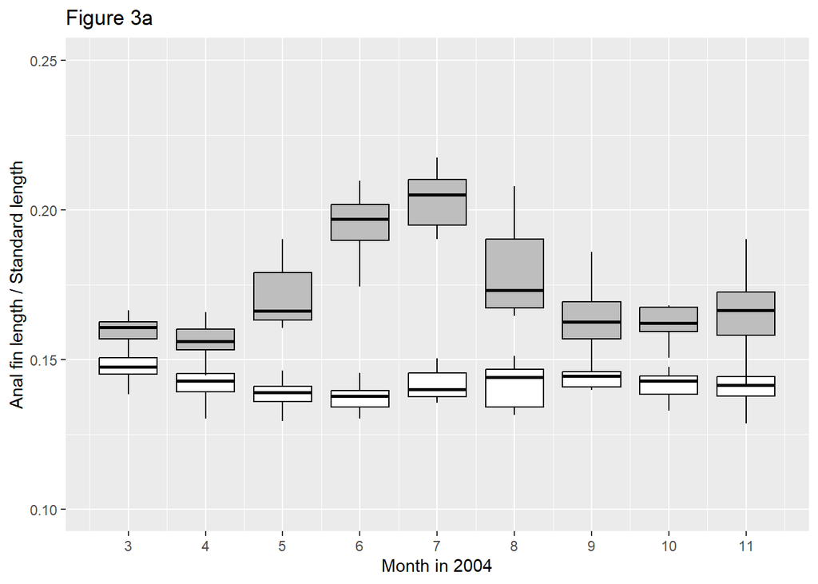

```r
fd2004 <- filter(d2004, sex == "f") # filter by sex
md2004 <- filter(d2004, sex == "m")

# AFL / SL Female
fig3aF<- ggplot(data = fd2004, aes(y = AFLmm/SLmm, x = month)) + geom_boxplot(na.rm = T, aes(group = month), outlier.shape = NA, color = "black", fill = "white") + scale_x_continuous(breaks = 1:12) + xlab("Month in 2004") + ylab("Anal fin length / Standard length") + coord_cartesian(ylim =c(0.1, 0.25)) # female boxplots displayed in white

# AFL / SL Male
fig3aM<- ggplot(data = md2004, aes(y = AFLmm/SLmm, x = month)) + geom_boxplot(na.rm = T, aes(group = month), outlier.shape = NA, color = "black", fill = "gray") + scale_x_continuous(breaks = 1:12) + xlab("Month") + ylab("Anal fin length / Standard length") + coord_cartesian(ylim =c(0.1, 0.25)) # male boxplots displayed in grey

combined_plot3a <- fig3aF +
  geom_boxplot(data = md2004, aes(y = AFLmm/SLmm, x = month, group = month),
  outlier.shape = NA, color = "black", fill = "gray") + ggtitle(label = "Figure 3a")
  # only way I could figure out how to overlay on the same axis

# Display the combined plot
print(combined_plot3a)
```

FIGURE 3B: 2013 AFL/SL by Month in Males & Females

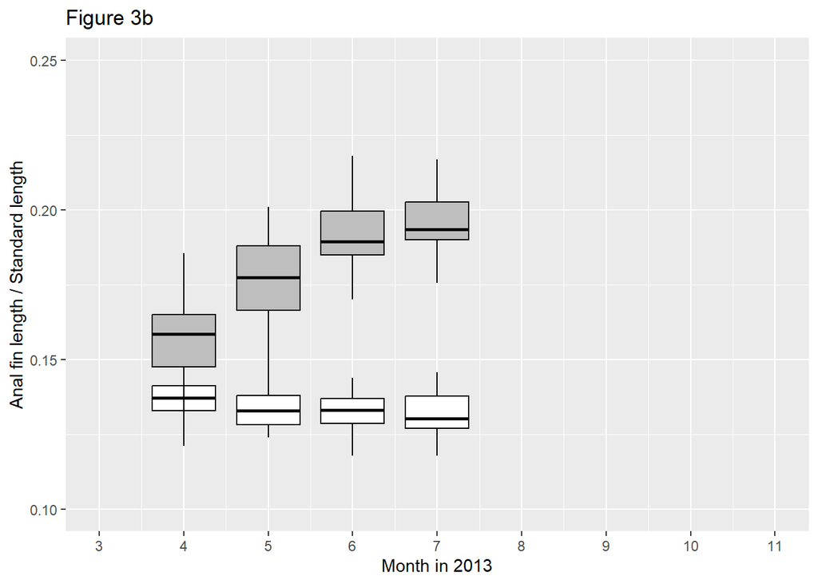

```r
fd2013 <- filter(d2013, sex == "f") # filter by sex
md2013 <- filter(d2013, sex == "m")

# AFL / SL Female
fig3bF<- ggplot(data = fd2013, aes(y = AFL/SL, x = month)) + geom_boxplot(na.rm = T, aes(group = month), outlier.shape = NA, color = "black", fill = "white") + scale_x_continuous(breaks = 1:12) + xlab("Month in 2013") + ylab("Anal fin length / Standard length")

# AFL / SL Male
fig3bM<- ggplot(data = md2013, aes(y = AFL/SL, x = month)) + geom_boxplot(na.rm = T, aes(group = month), outlier.shape = NA, color = "black", fill = "gray") + scale_x_continuous(breaks = 1:12) + xlab("Month") + ylab("Anal fin length / Standard length") + coord_cartesian(ylim =c(0.1, 0.25))

#combined plot overlaps AFL/SL Female and AFL/SL male to create the full figure 3b
combined_plot3b <- fig3bF +
  geom_boxplot(na.rm = T, data = md2013, aes(y = AFL/SL, x = month, group = month),
  outlier.shape = NA, color = "black", fill = "gray") + coord_cartesian(ylim =c(0.1, 0.25), xlim =c(3,11)) + ggtitle(label = "Figure 3b")

# Display the combined plot
print(combined_plot3b)
```

FIGURE 3C: 2013 DFL/SL by Month in Males and Females

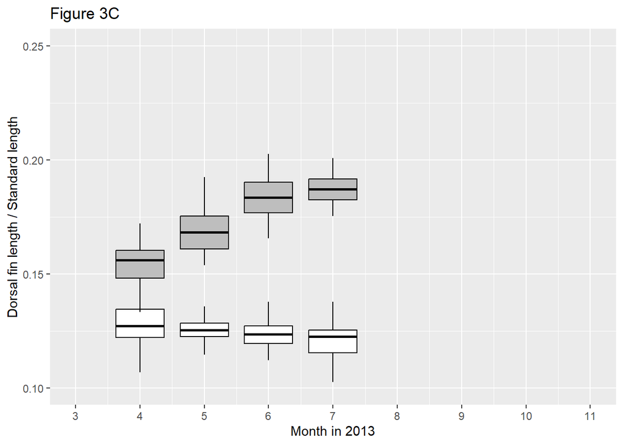

```r
# DFL / SL Female
fig3cF<- ggplot(data = fd2013, aes(y = DFL/SL, x = month)) + geom_boxplot(na.rm = T, aes(group = month), outlier.shape = NA, color = "black", fill = "white") + scale_x_continuous(breaks = 1:12) + xlab("Month in 2013") + ylab("Dorsal fin length / Standard length")

# DFL / SL Male
fig3cM<- ggplot(data = md2013, aes(y = DFL/SL, x = month)) + geom_boxplot(na.rm = T, aes(group = month), outlier.shape = NA, color = "black", fill = "gray") + scale_x_continuous(breaks = 1:12) + xlab("Month") + ylab("Dorsal fin length / Standard length") + coord_cartesian(ylim =c(0.1, 0.25))

#combined plot overlaps AFL/SL Female and AFL/SL male to create the full figure 3b
combined_plot3c <- fig3cF +
  geom_boxplot(na.rm = T, data = md2013, aes(y = DFL/SL, x = month, group = month),
  outlier.shape = NA, color = "black", fill = "gray") + coord_cartesian(ylim =c(0.1, 0.25), xlim =c(3,11)) + ggtitle(label = "Figure 3C")


# Display the combined plot
print(combined_plot3c)
```

INTERPRETATION OF THE FIGURE, COMMENTS, AND FULLY ARRANGED PLOTS

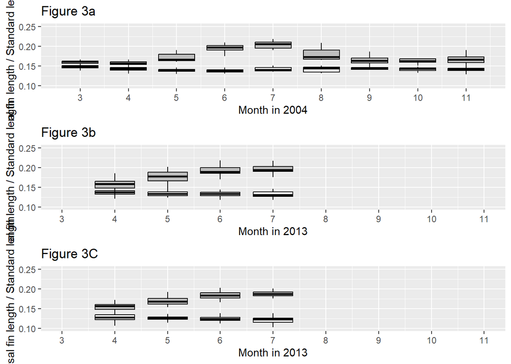

```r
# data on AFL/SL and DFL/SL for month 8 is missing from the 2013 dataset, but is presented in figure 3b. I am thus unable to make a perfect replicatio of their figure. This would likely also account for differences between my figure and the given figures for figure 2a, 2b, and 2c. This would also account for different F values found in the ANOVA test on AFL and DFL in 2013. However, the incomplete data still presents the same general findings as what is stated in the paper. AFL and DFL appears to grow significantly larger than that of females during the reproductive months (4-8), and appears to wax and wane as the season progresses.
grid.arrange(combined_plot3a, combined_plot3b, combined_plot3c, ncol = 1)
```

TABLE 1.

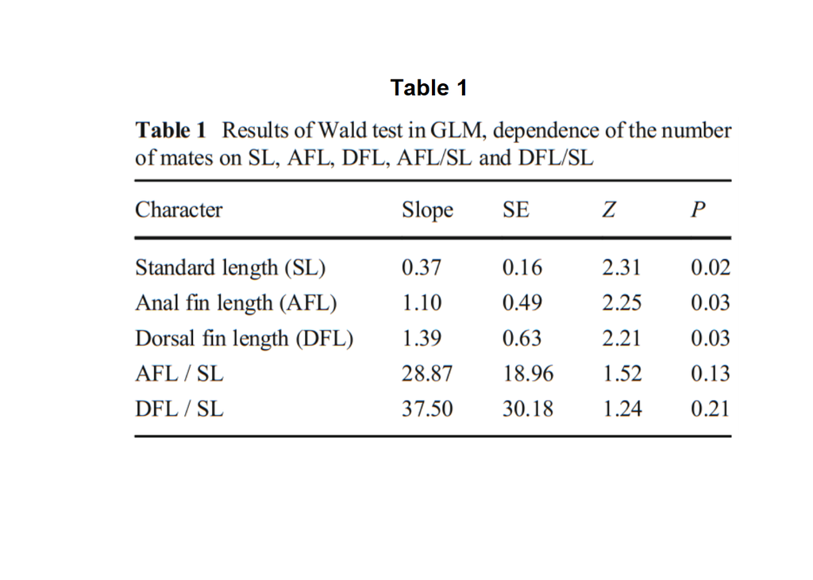

```r
# Table 1: presents the results of a Wald test of several GLM models testing whether the number of reproductions a male engages in is dependent on SL, AFL, DFL, AFL/SL, or DFL/SL.

FigureT1<- readImage("images/Table 1.PNG")

plotImageArray(FigureT1, main = "Table 1")
```

READ IN DATA & ORGANIZE

```r
dt1 <- read.csv("https://raw.githubusercontent.com/MaxxRAM/Data-Analysis-Replication/main/data/mateNumberAndfertilizationRate.csv")
head(dt1)
```

```
##   collectDate      fID    sizeF reproduct Fegg NonFegg    mID       SL       TL
## 1    20140618 618FR1f1 26.97465         1   19       2 618FR1 24.29007 29.52023
## 2    20140618 618FR1f2 26.60280         1   13       0 618FR1 24.29007 29.52023
## 3    20140618 618FR1f3 28.65016         1   28       0 618FR1 24.29007 29.52023
## 4    20140618 618FR1f4 26.41325         1   13       1 618FR1 24.29007 29.52023
## 5    20140618 618FR1f5 22.02803         0   NA      NA 618FR1 24.29007 29.52023
## 6    20140618 618FR2f1 23.78168         1   15       1 618FR2 22.83971 28.08759
##         BD      CFL      AFL      DFL  AFLratio  DFLratio
## 1 5.533445 5.230155 4.830852 4.394074 0.1988817 0.1809000
## 2 5.533445 5.230155 4.830852 4.394074 0.1988817 0.1809000
## 3 5.533445 5.230155 4.830852 4.394074 0.1988817 0.1809000
## 4 5.533445 5.230155 4.830852 4.394074 0.1988817 0.1809000
## 5 5.533445 5.230155 4.830852 4.394074 0.1988817 0.1809000
## 6 6.144237 5.247876 5.238579 4.433728 0.2293628 0.1941236
```

TABLE 1: Create GLM models for number of reproductions dependent on SL, AFL, DFL, AFLratio & DFLratio

```r
t1m1<- glm(data = dt1, reproduct ~ SL, family = binomial) #I am using the glm function from {lme4} where I can test whether or not a male reproduced as a binomial against SL, AFL, DFL, AFLratio, and DFLratio
t1m2<- glm(data = dt1, reproduct ~ AFL, family = binomial)
t1m3<- glm(data = dt1, reproduct ~ DFL, family = binomial)
t1m4<- glm(data = dt1, reproduct ~ AFLratio, family = binomial)
t1m5<- glm(data = dt1, reproduct ~ DFLratio, family = binomial)

(m1<- summary(t1m1)) #summary provides a wald test for each model
```

```
##
## Call:
## glm(formula = reproduct ~ SL, family = binomial, data = dt1)
##
## Coefficients:
##             Estimate Std. Error z value Pr(>|z|)
## (Intercept)  -7.3084     3.5410  -2.064   0.0390 *
## SL            0.3661     0.1587   2.306   0.0211 *
## ---
## Signif. codes:  0 '***' 0.001 '**' 0.01 '*' 0.05 '.' 0.1 ' ' 1
##
## (Dispersion parameter for binomial family taken to be 1)
##
##     Null deviance: 83.079  on 68  degrees of freedom
## Residual deviance: 77.378  on 67  degrees of freedom
## AIC: 81.378
##
## Number of Fisher Scoring iterations: 4
```